# HW4

### Homework 4

Jan Dziuba

### Dataset

I chose the MagicTelescope dataset.  
Dataset is used for classification of high energy gamma particles in a ground-based atmospheric Cherenkov gamma telescope using the imaging technique.  
For more detailed description check  
https://www.openml.org/search?type=data&sort=runs&id=1120&status=active

Dataset contains 10 features and 19020 samples.  
Classes are imbalanced with 1.8438995215311005 ratio.

#### Task A.

1. Train a tree-based ensemble model on the selected dataset; it can be one of random forest, GBM, CatBoost, XGBoost, LightGBM (various types) etc.

   I chose random forest.

shap

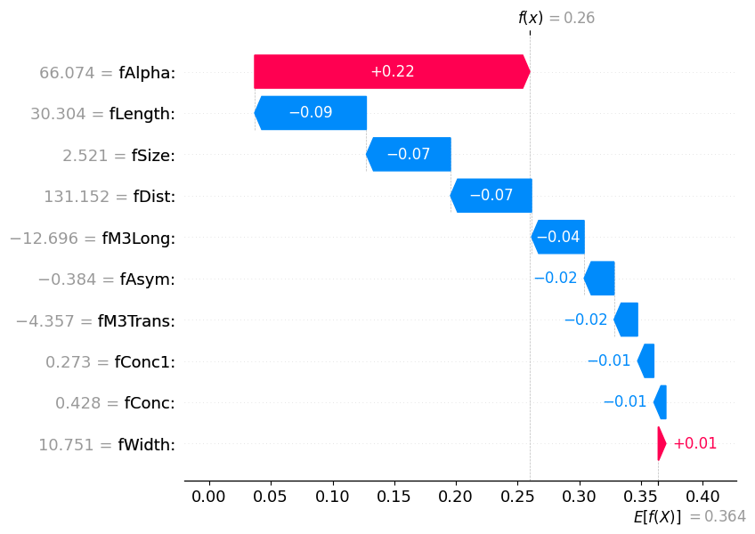

2* sample 2  
dalex

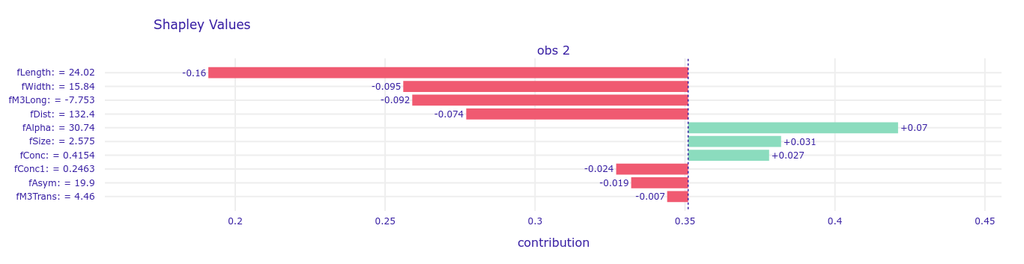

shap

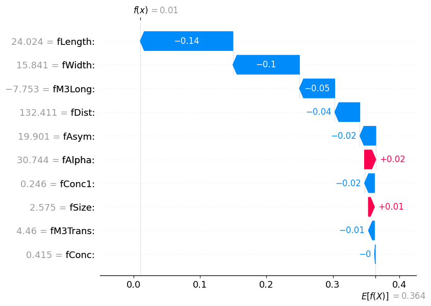

4. Find any two observations in the dataset, such that they have different variables of the highest importance, e.g. age and gender have the highest (absolute) attribution for observation A, but race and class are more important for observation B.

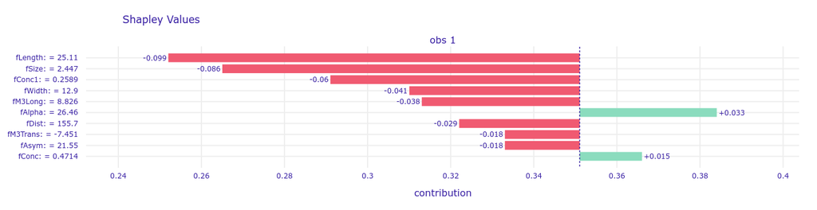

In obs 0 fAlpha is the most important, but in obs 1 is sixth most important variable, with fLength taking the lead

5. (If possible) Select one variable X and find two observations in the dataset such that for one observation, X has a positive attribution, and for the other observation, X has a negative attribution.

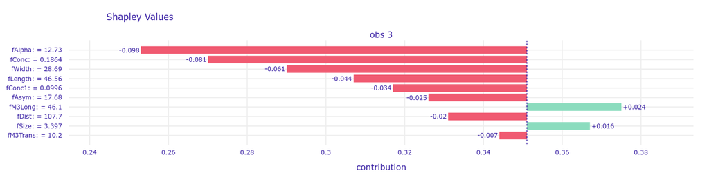

In obs 0 fAlpha has big positive attribution, but in obs 3 it has big negative attribution.  
fAlpha is angle of major axis with vector to origin.  
We can see that in obs 0 it is significantly bigger than in obs 3.

7. (Using one explanation package of choice) Train another model of any class: neural network, linear model, decision tree etc. and find an observation for which SHAP attributions are different between this model and the one trained in point (1).

For the second model i chose Logistic Regression.

Logistic Regression obs 0

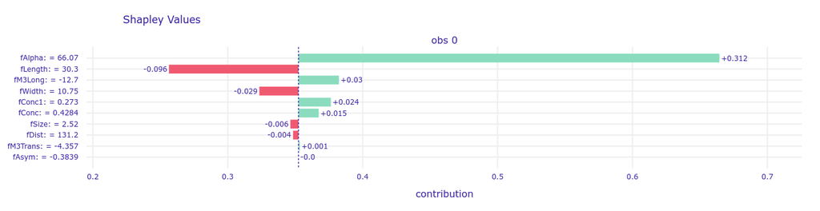

For 2 most important Random Forest variables Logistic Regression shows similar attribution. For other variables models differ significantly.  
It is actually enough for the models to predict opposite classes.

#### Task B.

Using shapley values formula for subsets

$${\displaystyle \phi _{j}(v)=\sum _{S\subseteq \mathcal{P}/ \{j\}}{\frac {|S|!\;\left(|\mathcal{P}|-|S|-1\right)!}{|\mathcal{P}|!}}\left(v(S\cup \{j\})-v(S)\right)}$$

Subsets of P not containing a are $\{\emptyset, \{B\}, \{C\}, \{B, C\}\}$

1* $\emptyset$ $$\frac{0!\cdot 2!}{3!}\left(v(A)-v(\emptyset)\right)=\frac{2}{6}\left(20-0\right) = \frac{20}{3}$$

2* $\{B\}$ $$\frac{1!\cdot 1!}{3!}\left(v(A,B)-v(B\right)=\frac{1}{6}\left(60-20\right) = \frac{20}{3}$$

3* $\{C\}$ $$\frac{1!\cdot 1!}{3!}\left(v(A,C)-v(C\right)=\frac{1}{6}\left(70-60\right) = \frac{10}{6}$$

4* $\{B, C\}$ $$\frac{2!\cdot 0!}{3!}\left(v(A,B,C)-v(B,C\right)=\frac{2}{6}\left(100-70\right) = 10$$

Shapley value of player A $=\tfrac{20}{3}+\tfrac{20}{3}+\tfrac{10}{6}+10=25$

### Appendix

```python
import numpy as np
import pandas as pd
import random

import matplotlib.pyplot as plt
import sklearn
from sklearn.model_selection import train_test_split

from sklearn.linear_model import LogisticRegression
from sklearn.ensemble import RandomForestClassifier

from sklearn.metrics import accuracy_score, precision_score, recall_score, roc_auc_score, f1_score

import dalex as dx
import shap
import xgboost
import lime
```

```python
{package.__name__: package.__version__ for package in [dx, xgboost, sklearn, pd, np]} | {lime.__name__: "0.2.0.1"}
```

```
{'dalex': '1.6.0',
 'xgboost': '1.7.5',
 'sklearn': '1.2.1',
 'pandas': '2.0.2',
 'numpy': '1.24.3',
 'lime': '0.2.0.1'}
```

```python
dataset = pd.read_csv('https://raw.githubusercontent.com/adrianstando/imbalanced-benchmarking-set/main/datasets/MagicTelescope.csv', index_col=0)
```

```python
dataset
```

|  | fLength: | fWidth: | fSize: | fConc: | fConc1: | fAsym: | fM3Long: | fM3Trans: | fAlpha: | fDist: | TARGET |
| --- | --- | --- | --- | --- | --- | --- | --- | --- | --- | --- | --- |
| 0 | 28.7967 | 16.0021 | 2.6449 | 0.3918 | 0.1982 | 27.7004 | 22.0110 | -8.2027 | 40.0920 | 81.8828 | g |
| 1 | 31.6036 | 11.7235 | 2.5185 | 0.5303 | 0.3773 | 26.2722 | 23.8238 | -9.9574 | 6.3609 | 205.2610 | g |
| 2 | 162.0520 | 136.0310 | 4.0612 | 0.0374 | 0.0187 | 116.7410 | -64.8580 | -45.2160 | 76.9600 | 256.7880 | g |
| 3 | 23.8172 | 9.5728 | 2.3385 | 0.6147 | 0.3922 | 27.2107 | -6.4633 | -7.1513 | 10.4490 | 116.7370 | g |
| 4 | 75.1362 | 30.9205 | 3.1611 | 0.3168 | 0.1832 | -5.5277 | 28.5525 | 21.8393 | 4.6480 | 356.4620 | g |
| ... | ... | ... | ... | ... | ... | ... | ... | ... | ... | ... | ... |
| 19015 | 21.3846 | 10.9170 | 2.6161 | 0.5857 | 0.3934 | 15.2618 | 11.5245 | 2.8766 | 2.4229 | 106.8258 | h |
| 19016 | 28.9452 | 6.7020 | 2.2672 | 0.5351 | 0.2784 | 37.0816 | 13.1853 | -2.9632 | 86.7975 | 247.4560 | h |
| 19017 | 75.4455 | 47.5305 | 3.4483 | 0.1417 | 0.0549 | -9.3561 | 41.0562 | -9.4662 | 30.2987 | 256.5166 | h |
| 19018 | 120.5135 | 76.9018 | 3.9939 | 0.0944 | 0.0683 | 5.8043 | -93.5224 | -63.8389 | 84.6874 | 408.3166 | h |
| 19019 | 187.1814 | 53.0014 | 3.2093 | 0.2876 | 0.1539 | -167.3125 | -168.4558 | 31.4755 | 52.7310 | 272.3174 | h |

19020 rows × 11 columns

```python
dataset.info()
```

```
<class 'pandas.core.frame.DataFrame'>
Index: 19020 entries, 0 to 19019
Data columns (total 11 columns):
 #   Column     Non-Null Count  Dtype
---  ------     --------------  -----
 0   fLength:   19020 non-null  float64
 1   fWidth:    19020 non-null  float64
 2   fSize:     19020 non-null  float64
 3   fConc:     19020 non-null  float64
 4   fConc1:    19020 non-null  float64
 5   fAsym:     19020 non-null  float64
 6   fM3Long:   19020 non-null  float64
 7   fM3Trans:  19020 non-null  float64
 8   fAlpha:    19020 non-null  float64
 9   fDist:     19020 non-null  float64
 10  TARGET     19020 non-null  object
dtypes: float64(10), object(1)
memory usage: 1.7+ MB
```

```python
dataset.describe()
```

|  | fLength: | fWidth: | fSize: | fConc: | fConc1: | fAsym: | fM3Long: | fM3Trans: | fAlpha: | fDist: |
| --- | --- | --- | --- | --- | --- | --- | --- | --- | --- | --- |
| count | 19020.000000 | 19020.000000 | 19020.000000 | 19020.000000 | 19020.000000 | 19020.000000 | 19020.000000 | 19020.000000 | 19020.000000 | 19020.000000 |
| mean | 53.250154 | 22.180966 | 2.825017 | 0.380327 | 0.214657 | -4.331745 | 10.545545 | 0.249726 | 27.645707 | 193.818026 |
| std | 42.364855 | 18.346056 | 0.472599 | 0.182813 | 0.110511 | 59.206062 | 51.000118 | 20.827439 | 26.103621 | 74.731787 |
| min | 4.283500 | 0.000000 | 1.941300 | 0.013100 | 0.000300 | -457.916100 | -331.780000 | -205.894700 | 0.000000 | 1.282600 |
| 25% | 24.336000 | 11.863800 | 2.477100 | 0.235800 | 0.128475 | -20.586550 | -12.842775 | -10.849375 | 5.547925 | 142.492250 |
| 50% | 37.147700 | 17.139900 | 2.739600 | 0.354150 | 0.196500 | 4.013050 | 15.314100 | 0.666200 | 17.679500 | 191.851450 |
| 75% | 70.122175 | 24.739475 | 3.101600 | 0.503700 | 0.285225 | 24.063700 | 35.837800 | 10.946425 | 45.883550 | 240.563825 |
| max | 334.177000 | 256.382000 | 5.323300 | 0.893000 | 0.675200 | 575.240700 | 238.321000 | 179.851000 | 90.000000 | 495.561000 |

```python
X = dataset.drop(columns=['TARGET'])
y = dataset['TARGET']
```

```python
# map y values to 0 and 1, but keep y as a pandas Series
y = y.map({'g': 0, 'h': 1})
```

```python
X_train, X_test, Y_train, Y_test = train_test_split(X, y, test_size=0.2, random_state=42)
```

```python
def evaluate_model(model, X_test, Y_test):
    pred = model.predict(X_test)
    pred_proba = model.predict_proba(X_test)[:, 1]

    accuracy = accuracy_score(Y_test, pred)
    precision = precision_score(Y_test, pred)
    recall = recall_score(Y_test, pred)
    auc = roc_auc_score(Y_test, pred_proba)
    f1 = f1_score(Y_test, pred)

    print('Accuracy: {}'.format(accuracy))
    print('Precision: {}'.format(precision))
    print('Recall: {}'.format(recall))
    print('AUC: {}'.format(auc))
    print('F1: {}'.format(f1))
```

```python
rf = RandomForestClassifier()
rf.fit(X_train, Y_train)
```

```
RandomForestClassifier()
```

```python
evaluate_model(rf, X_test, Y_test)
```

```
Accuracy: 0.8780231335436383
Precision: 0.8716216216216216
Recall: 0.7678571428571429
AUC: 0.9314462954897407
F1: 0.8164556962025317
```

1. Select two observations from the dataset and calculate the model's prediction.

```python
obs = [0, 2]
rf.predict(X_train.iloc[obs])
```

```
array([0, 0])
```

```python
# print the probability of each class for obs
rf.predict_proba(X_train.iloc[obs])
```

```
array([[0.74, 0.26],
       [0.99, 0.01]])
```

3. Next, for the same observations, calculate the decomposition of predictions, so-called variable attributions,

using SHAP from two packages of choice, e.g. for Python: dalex and shap, for R: DALEX and iml.

dalex

```python
explainer = dx.Explainer(rf, X_train, Y_train)
explainer.model_performance()
```

[output not shown]

```
  -> residuals         : min = -0.44, mean = 0.000171, max = 0.48
  -> model_info        : package sklearn

A new explainer has been created!
```

|  | recall | precision | f1 | accuracy | auc |
| --- | --- | --- | --- | --- | --- |
| RandomForestClassifier | 1.0 | 1.0 | 1.0 | 1.0 | 1.0 |

```python
for i in range(5):
    shap_attributions = [explainer.predict_parts(X_train.iloc[[i]], type="shap", label=f'obs {i}')]
    shap_attributions[0].plot(shap_attributions[1::])
```

```python
for i in range(5):
    bd_attributions = [explainer.predict_parts(X_train.iloc[[i]], type="break_down", label=f'obs {i}')]
    bd_attributions[0].plot(bd_attributions[1::])
```

[output not shown]

shap

```python
shap_explainer = shap.explainers.Tree(rf, data=X_train, model_output="probability")
```

```python
shap_values = shap_explainer(X_train[:5])[:,:,1]
```

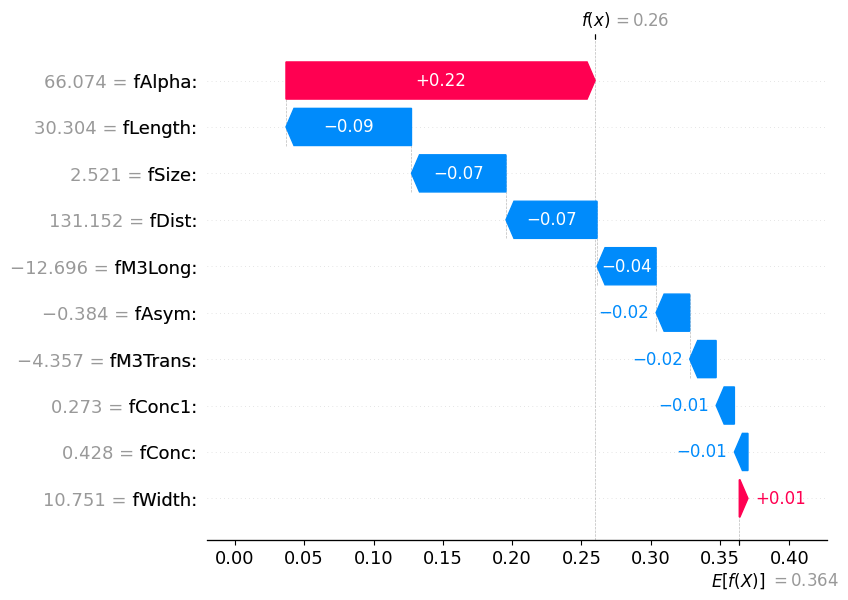

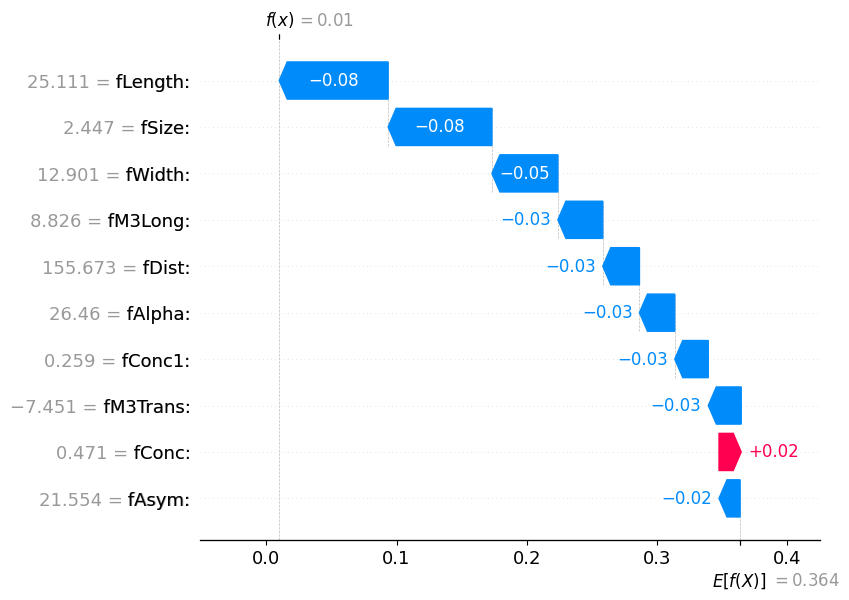

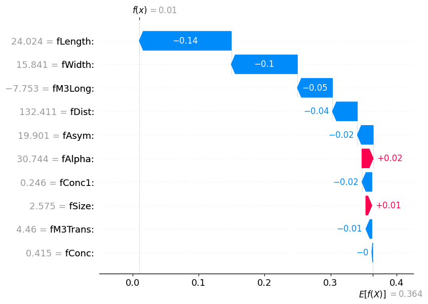

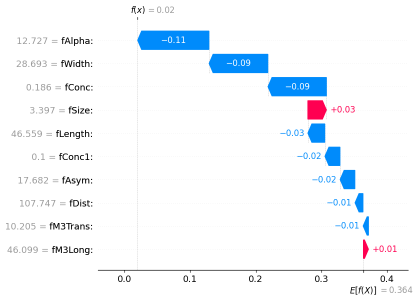

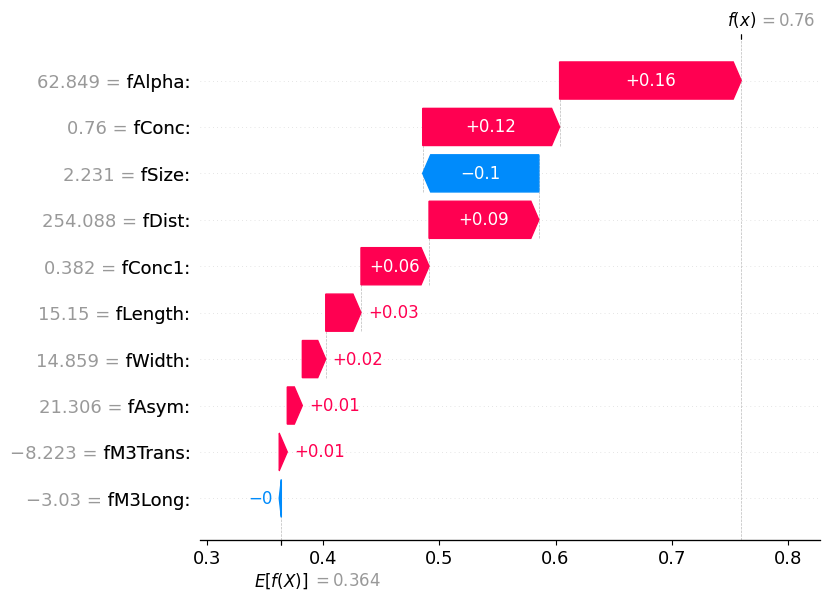

```python
for i in range(5):
    shap.plots.waterfall(shap_values[i])
```

7. (Using one explanation package of choice) Train another model of any class: neural network, linear model, decision tree etc. and find an observation for which SHAP attributions are different between this model and the one trained in point (1).

```python
lr = LogisticRegression()
lr.fit(X_train, Y_train)
```

```
LogisticRegression()
```

```python
evaluate_model(lr, X_test, Y_test)
```

```
Accuracy: 0.7862776025236593
Precision: 0.7497648165569144
Recall: 0.5930059523809523
AUC: 0.8426260646535035
F1: 0.6622351474864977
```

```python
obs = [0, 2]
lr.predict(X_train.iloc[obs])
```

```
array([1, 0])
```

```python
# print the probability of each class for obs
lr.predict_proba(X_train.iloc[obs])
```

```
array([[0.39983692, 0.60016308],
       [0.78925232, 0.21074768]])
```

```python
lr_explainer = dx.Explainer(lr, X_train, Y_train)
lr_explainer.model_performance()
```

[output not shown]

|  | recall | precision | f1 | accuracy | auc |
| --- | --- | --- | --- | --- | --- |
| LogisticRegression | 0.582335 | 0.74682 | 0.6544 | 0.783977 | 0.839869 |

```python
for i in range(5):
    shap_attributions = [lr_explainer.predict_parts(X_train.iloc[[i]], type="shap", label=f'obs {i}')]
    shap_attributions[0].plot(shap_attributions[1::])
```

```python
for i in range(5):
    bd_attributions = [lr_explainer.predict_parts(X_train.iloc[[i]], type="break_down", label=f'obs {i}')]
    bd_attributions[0].plot(bd_attributions[1::])
```

[output not shown]